# Quiz 2

# Quiz 2 – More R Coding…

## This quiz covers competencies you should know by the first day of class.

## The first ten questions are intended to be basic.

## The final five questions are more advanced.

## An answer key will be provided by Tuesday, July 24.

## NOTE: Most students find it helpful to code in R using R-Studio.

## This involves installing R, and installing R-Studio, and then

## running R-Studio. Google it if you run into problems, and

## if Google can’t answer your questions, feel free to email me.

# Load the Matching library, as described at the beginning of the prior quiz

# (Quiz 1). If you’ve never installed this Matching library before,

# you’ll have to begin by doing so – one way is to use use “install.packages()”,

# but there are also ‘point-and-click’ ways to do it.

# So—the first step is to install the library, and the next step is to load it.

```r
library(Matching)
```

# The “Matching” library comes with a data set called

# GerberGreenImai which relates to a series of published papers.

# You can see some of those papers if (after loading the library)

# you type:

```r
?GerberGreenImai
```

# This command opens the help page for the data set. At the bottom of the help page,

# you’ll see a list of 4 relevant published papers.

# To load the data set into working memory, type:

```r
data(GerberGreenImai)
```

# To take a quick look at the data set, type:

```r
head(GerberGreenImai)
```

|  | PERSONS | WARD | QUESTION | MAILGRP | PHONEGRP | PERSNGRP | APPEAL | CONTACT | MAILINGS | AGE | MAJORPTY | VOTE96.0 | VOTE96.1 | MAILCALL | VOTED98 | PHNSCRPT | DIS.MC | DIS.PHN | PHN.C | PHNTRT1 | PHNTRT2 | PHN.C1 | PHN.C2 | NEW | phone | AGE2 |
| --- | --- | --- | --- | --- | --- | --- | --- | --- | --- | --- | --- | --- | --- | --- | --- | --- | --- | --- | --- | --- | --- | --- | --- | --- | --- | --- |
| 1221 | 2 | 13 | 0 | 0 | 1 | 0 | 3 | 0 | 0 | 74 | 1 | 0 | 1 | 0 | 1 | 6 | 99 | 1 | 1 | 1 | 1 | 1 | 1 | 0 | 1 | 54.76 |
| 1228 | 2 | 24 | 1 | 0 | 1 | 0 | 3 | 0 | 0 | 37 | 0 | 0 | 1 | 0 | 0 | 6 | 99 | 1 | 1 | 1 | 1 | 1 | 1 | 0 | 1 | 13.69 |
| 1236 | 2 | 29 | 1 | 0 | 1 | 0 | 2 | 0 | 0 | 24 | 1 | 0 | 1 | 0 | 1 | 2 | 99 | 1 | 1 | 1 | 1 | 1 | 1 | 0 | 1 | 5.76 |
| 1242 | 2 | 10 | 1 | 0 | 1 | 0 | 2 | 0 | 0 | 81 | 1 | 0 | 1 | 0 | 1 | 2 | 99 | 1 | 1 | 1 | 1 | 1 | 1 | 0 | 1 | 65.61 |
| 1279 | 2 | 21 | 0 | 0 | 1 | 0 | 2 | 0 | 0 | 34 | 1 | 0 | 0 | 0 | 0 | 2 | 99 | 1 | 1 | 1 | 1 | 1 | 1 | 1 | 1 | 11.56 |
| 1289 | 2 | 20 | 1 | 0 | 1 | 0 | 3 | 0 | 0 | 54 | 1 | 1 | 0 | 0 | 1 | 6 | 99 | 1 | 1 | 1 | 1 | 1 | 1 | 0 | 1 | 29.16 |

# Question 1 (using “dim”)

What are the dimensions of the data set (how many rows and columns)?

```r
dim(GerberGreenImai)
```

```
[1] 10829    26
```

# Question 2 (using “names”)

# What are the variable names?

```r
names(GerberGreenImai)
```

```
 [1] "PERSONS"  "WARD"     "QUESTION" "MAILGRP"  "PHONEGRP" "PERSNGRP" "APPEAL"   "CONTACT"  "MAILINGS" "AGE"      "MAJORPTY"
[12] "VOTE96.0" "VOTE96.1" "MAILCALL" "VOTED98"  "PHNSCRPT" "DIS.MC"   "DIS.PHN"  "PHN.C"    "PHNTRT1"  "PHNTRT2"  "PHN.C1"
[23] "PHN.C2"   "NEW"      "phone"    "AGE2"
```

# Question 3 (using “is.na”)

# Is there any missing data? If so, how many elements are missing

# and which rows contain the missing data?

```r
any(is.na(GerberGreenImai))
```

```
[1] FALSE
```

```r
which(is.na(GerberGreenImai), arr.ind = TRUE)
```

```
     row col
```

# Question 4 (using the “mode” function, or “is.factor”)

# In this data set, each column is a variable (e.g., “AGE”, “WARD”, etc.).

# Which of these variables (if any) is a factor?

```r
names(GerberGreenImai)[sapply(GerberGreenImai, is.factor)]
```

```
[1] "WARD"
```

# Question 5 (using the “mode” function)

# Code a for loop that outputs column name and variable type, per the below format:

# column name #1 variable type #1

# column name #2 variable type #2

# column name #3 variable type #3

# etc., etc., etc., type of each

```r
for (i in (1:ncol(GerberGreenImai))) { print( cbind(paste('column name:', colnames(GerberGreenImai)[i]),paste('variable type:',sapply(GerberGreenImai, class)[i]))) }
```

```
     [,1]                   [,2]
[1,] "column name: PERSONS" "variable type: integer"
     [,1]                [,2]
[1,] "column name: WARD" "variable type: factor"
     [,1]                    [,2]
[1,] "column name: QUESTION" "variable type: integer"
     [,1]                   [,2]
[1,] "column name: MAILGRP" "variable type: integer"
     [,1]                    [,2]
[1,] "column name: PHONEGRP" "variable type: integer"
     [,1]                    [,2]
[1,] "column name: PERSNGRP" "variable type: integer"
     [,1]                  [,2]
[1,] "column name: APPEAL" "variable type: integer"
     [,1]                   [,2]
[1,] "column name: CONTACT" "variable type: integer"
     [,1]                    [,2]
[1,] "column name: MAILINGS" "variable type: integer"
     [,1]               [,2]
[1,] "column name: AGE" "variable type: integer"
     [,1]                    [,2]
[1,] "column name: MAJORPTY" "variable type: integer"
     [,1]                    [,2]
[1,] "column name: VOTE96.0" "variable type: integer"
     [,1]                    [,2]
[1,] "column name: VOTE96.1" "variable type: integer"
     [,1]                    [,2]
[1,] "column name: MAILCALL" "variable type: integer"
     [,1]                   [,2]
[1,] "column name: VOTED98" "variable type: integer"
     [,1]                    [,2]
[1,] "column name: PHNSCRPT" "variable type: integer"
     [,1]                  [,2]
[1,] "column name: DIS.MC" "variable type: integer"
     [,1]                   [,2]
[1,] "column name: DIS.PHN" "variable type: integer"
     [,1]                 [,2]
[1,] "column name: PHN.C" "variable type: integer"
     [,1]                   [,2]
[1,] "column name: PHNTRT1" "variable type: integer"
     [,1]                   [,2]
[1,] "column name: PHNTRT2" "variable type: integer"
     [,1]                  [,2]
[1,] "column name: PHN.C1" "variable type: integer"
     [,1]                  [,2]
[1,] "column name: PHN.C2" "variable type: integer"
     [,1]               [,2]
[1,] "column name: NEW" "variable type: numeric"
     [,1]                 [,2]
[1,] "column name: phone" "variable type: numeric"
     [,1]                [,2]
[1,] "column name: AGE2" "variable type: numeric"
```

# Question 6

# What do you think the variable AGE2 represents?

```r
## Using
## ?GerberGreenImai and checking function arguments gives
## Age Squared/100
```

# Question 7

# Which individuals (and how many) voted in 1978?

```r
which(GerberGreenImai["VOTED98"] == 1)
```

```
   [1]    1    3    4    6    7    8    9   10   11   13   15   16   19   20   21   22   23   24   26   28   29   30   31   32   33
  [26]   34   35   36   37   38   39   40   41   42   43   44   45   46   47   49   51   52   53   54   55   56   62   65   66   67
  [51]   68   69   71   72   73   75   77   78   79   82   83   88   90   91   92   95   96   97   98  104  106  107  110  111  115
  [76]  120  123  124  125  126  127  128  130  136  137  138  140  144  150  151  153  154  155  163  164  165  166  167  168  172
 [101]  175  176  180  183  184  192  194  195  196  198  205  206  208  211  214  215  216  217  218  219  220  221  223  225  227
 [126]  228  229  232  233  234  235  239  246  250  253  254  255  258  261  262  263  264  266  268  274  275  276  277  278  280
 [151]  283  286  288  290  291  292  293  297  298  302  305  306  307  308  309  310  312  314  315  316  317  321  322  323  324
 [176]  325  327  330  332  333  334  336  338  340  341  342  347  349  350  351  352  353  354  357  359  361  363  364  368  371
 [201]  372  374  377  378  379  381  382  384  385  386  394  395  396  397  399  400  402  403  404  406  407  409  410  412  414
 [226]  418  419  420  423  427  429  430  433  435  440  447  448  454  458  460  462  464  469  471  472  475  481  482  485  486
 [251]  487  488  491  494  498  501  510  511  514  518  519  520  523  524  525  526  529  532  533  534  537  539  542  543  545
 [276]  548  549  551  552  553  554  555  556  557  561  562  563  566  567  569  572  575  576  579  580  582  584  587  588  589
 [301]  593  595  600  601  604  606  609  611  613  614  615  617  619  624  625  626  628  632  634  635  636  637  638  642  644
 [326]  645  653  654  656  657  665  666  667  677  678  680  682  683  684  685  686  692  695  696  700  701  702  703  709  717
 [351]  720  725  727  729  732  734  736  737  738  740  745  747  749  752  753  758  760  761  773  774  775  780  783  789  791
```

[output cut: 26 more lines]

```r
sum(GerberGreenImai["VOTED98"])
```

```
[1] 4861
```

# Question 8

# Which individuals (and how many) have age > 35 and did NOT vote in 1978?

```r
which(GerberGreenImai["VOTED98"] == 0 & GerberGreenImai["AGE"] > 35)
```

```
   [1]    2   14   18   25   27   48   50   57   58   59   60   61   63   64   74   76   80   85   87   89   93   99  101  103  105
  [26]  109  113  114  116  117  118  119  122  131  132  133  134  139  142  143  145  148  152  157  158  159  160  161  162  171
  [51]  178  179  181  182  185  187  188  190  191  193  197  199  200  201  203  204  210  224  236  237  238  240  241  243  244
  [76]  245  248  249  251  252  256  259  260  265  267  269  271  279  281  282  285  287  295  296  299  301  303  313  320  326
 [101]  343  344  346  348  356  358  362  365  367  369  376  387  388  389  391  393  398  413  415  416  417  421  424  425  431
 [126]  434  437  438  441  444  446  449  450  452  453  455  456  457  463  465  468  470  473  476  478  480  484  489  490  495
 [151]  502  504  506  507  508  509  512  513  515  521  522  527  528  530  531  535  538  540  541  544  546  547  558  564  565
 [176]  570  571  581  583  585  586  590  591  592  594  596  597  602  603  605  607  608  612  621  622  627  629  630  631  633
 [201]  641  643  646  647  648  650  651  658  659  661  664  669  671  672  673  675  676  679  681  689  693  697  698  699  705
 [226]  707  708  710  711  712  715  716  722  723  724  726  728  730  731  741  744  746  750  751  755  756  757  759  764  765
 [251]  766  767  768  771  772  776  777  781  782  786  787  788  790  793  799  804  805  807  819  823  824  829  832  833  835
 [276]  836  837  842  846  852  854  856  861  862  864  865  866  867  877  878  882  883  884  886  890  891  893  894  897  902
 [301]  903  906  914  916  918  920  927  929  930  932  936  938  939  940  941  943  944  948  950  952  965  966  968  969  971
 [326]  973  977  978  979  981  984  986  987  990  991  992  996  999 1001 1002 1003 1005 1011 1013 1015 1024 1025 1027 1028 1029
 [351] 1030 1033 1038 1044 1052 1054 1059 1069 1070 1072 1074 1082 1083 1095 1103 1104 1106 1110 1112 1115 1116 1122 1125 1127 1132
```

[output cut: 26 more lines]

```r
nrow(GerberGreenImai[GerberGreenImai["VOTED98"] == 0 & GerberGreenImai["AGE"] > 35,])
```

```
[1] 3662
```

# Question 9

# What line of code eliminates all rows that satisfy the conditions of Question 8?

```r
GerberGreenImai[!(GerberGreenImai["VOTED98"] == 0 & GerberGreenImai["AGE"] > 35),]
```

# Question 10

# Append a column that records a “1” if Question 8’s conditions satisfy, 0 if not.

# Congrats, you just created a dummy variable! Google it if you have questions.

```r
GerberGreenImai['DummyCol'] = as.integer((GerberGreenImai["VOTED98"] == 0 & GerberGreenImai["AGE"] > 35))
```

# Question 11

# Write a function that performs the algorithm you identified in Question 6.

```r
all((GerberGreenImai$AGE ^2)/100 == GerberGreenImai$AGE2)
```

```
[1] TRUE
```

# Question 12

# Run a regression w/ AGE2 and AGE as dependent and independent vars (respectively).

# Do you get statistically significant results? Is there something causal going on?

# Does the model make predictions that are not possible in the real world? Explain.

```r
summary(lm(AGE2 ~ AGE, data= GerberGreenImai))
```

```
Call:
lm(formula = AGE2 ~ AGE, data = GerberGreenImai)

Residuals:
    Min      1Q  Median      3Q     Max
-3.6867 -2.9736 -0.9519  2.2924 15.1959

Coefficients:
             Estimate Std. Error t value Pr(>|t|)
(Intercept) -24.98031    0.09393  -265.9   <2e-16 ***
AGE           1.07087    0.00177   605.0   <2e-16 ***
---
Signif. codes:  0 ‘***’ 0.001 ‘**’ 0.01 ‘*’ 0.05 ‘.’ 0.1 ‘ ’ 1

Residual standard error: 3.463 on 10827 degrees of freedom
Multiple R-squared:  0.9713,    Adjusted R-squared:  0.9713
F-statistic: 3.661e+05 on 1 and 10827 DF,  p-value: < 2.2e-16
```

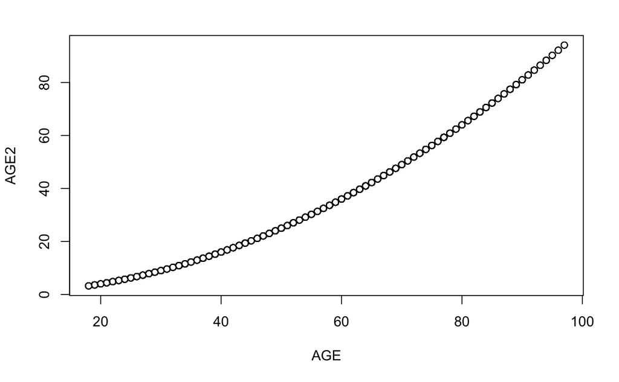

```r
plot(AGE2 ~ AGE, data = GerberGreenImai)
```

Makes a linear model that stretches on forever - there is a limit to where the model makes sense.

# Question 13 (hint: see the help page for “formula”)

# Consider the following code:

reg1 <- lm(PHN.C1 ~ PERSONS + VOTE96.1 + NEW + MAJORPTY + AGE + WARD + I(PERSONS*VOTE96.1), data=GerberGreenImai[c(1:1000),]) # you can then type something like “summary(reg1)”…

# This regression predicts whether or not a subject received a get-out-the-vote

# phone call based on the first 1000 observations.

# What is meant by I(PERSONS*VOTE96.1)? Use the resulting regression # model to make a prediction for individuals in rows 1001 and 1002. Do these # predictions make sense? Why or why not?

```r
summary(lm(PHN.C1 ~ PERSONS, data=GerberGreenImai[c(1:1000),]))
```

```
Call:
lm(formula = PHN.C1 ~ PERSONS, data = GerberGreenImai[c(1:1000),
    ])

Residuals:
   Min     1Q Median     3Q    Max
-0.064 -0.064 -0.064 -0.064  0.936

Coefficients: (1 not defined because of singularities)
            Estimate Std. Error t value Pr(>|t|)
(Intercept) 0.064000   0.007744   8.265 4.42e-16 ***
PERSONS           NA         NA      NA       NA
---
Signif. codes:  0 ‘***’ 0.001 ‘**’ 0.01 ‘*’ 0.05 ‘.’ 0.1 ‘ ’ 1

Residual standard error: 0.2449 on 999 degrees of freedom
```

```r
#summary(PHN.C1 ~ PERSONS + VOTE96.1 + NEW + MAJORPTY + AGE + WARD + I(PERSONS*VOTE96.1), data=GerberGreenImai[c(1:1000),])
```

# Question 14

# Consider the “WARD” variable. Observe the first 20 elements.

# What happens when you perform arithmetic or statistical operations on these

# elements? Why? Provide intuition for the result you obtain.

```r
GerberGreenImai$WARD[1:20]
```

```
 [1] 13 24 29 10 21 20 18 27 4  17 26 17 9  26 18 27 18 27 10 17
Levels: 2 3 4 5 6 7 8 9 10 11 12 13 14 15 16 17 18 19 20 21 22 23 24 25 26 27 28 29 30
```

```r
GerberGreenImai$WARD[1]
```

```
[1] 13
Levels: 2 3 4 5 6 7 8 9 10 11 12 13 14 15 16 17 18 19 20 21 22 23 24 25 26 27 28 29 30
```

```r
GerberGreenImai$WARD[2]
```

```
[1] 24
Levels: 2 3 4 5 6 7 8 9 10 11 12 13 14 15 16 17 18 19 20 21 22 23 24 25 26 27 28 29 30
```

```r
GerberGreenImai$WARD[1] + GerberGreenImai$WARD[2]
```

```
‘+’ not meaningful for factors
```

```
[1] NA
```

Not meaningful for factors because Ward 13 + Ward 24 != Ward 37

# Question 15

# Write code that takes the “WARD” variable and creates dummy variables for

# each individual ward. We can call this “dummy-fying” a categorical variable.

# Given your answer to Question 14, do you see why you would want to “dummy-fy”

# this variable prior to performing statistical analysis on it (and

# variables likes this one)?

```r
model.matrix(~GerberGreenImai$WARD)
```

```
      (Intercept) GerberGreenImai$WARD3 GerberGreenImai$WARD4 GerberGreenImai$WARD5 GerberGreenImai$WARD6 GerberGreenImai$WARD7
1               1                     0                     0                     0                     0                     0
2               1                     0                     0                     0                     0                     0
3               1                     0                     0                     0                     0                     0
4               1                     0                     0                     0                     0                     0
5               1                     0                     0                     0                     0                     0
6               1                     0                     0                     0                     0                     0
7               1                     0                     0                     0                     0                     0
8               1                     0                     0                     0                     0                     0
9               1                     0                     1                     0                     0                     0
10              1                     0                     0                     0                     0                     0
11              1                     0                     0                     0                     0                     0
12              1                     0                     0                     0                     0                     0
13              1                     0                     0                     0                     0                     0
14              1                     0                     0                     0                     0                     0
```

[output cut: 201 more lines]